### DABUKURI

#### Dados do Imóvel

Tipo de Imóvel: **RURAL**; Uso: **CASA**;

Proprietário: **Auriely da costa Soares** ; CPF: **004.766.572-61**; Endereço: **av Palmeira do Miriti, casa nº9, Avenida Palmeira do Miriti, Distrito Industrial II - 69075, Manaus, Brasil**; Comarca: **4º Registro de Imóveis de Manaus**; Área: **166m<sup>2</sup>**; Perímetro: **56m**;

Descrição: Projeto, Levantamento Topográfico, Planta e Memorial descritivo

| Marcos | Coordenadas |
| --- | --- |
| M01 | 3°4′8,1″S / 59°54′53,1″W |
| M02 | 3°4′7,9″S / 59°54′53,2″W |
| M03 | 3°4′7,6″S / 59°54′52,6″W |
| M04 | 3°4′7,9″S / 59°54′52,5″W |

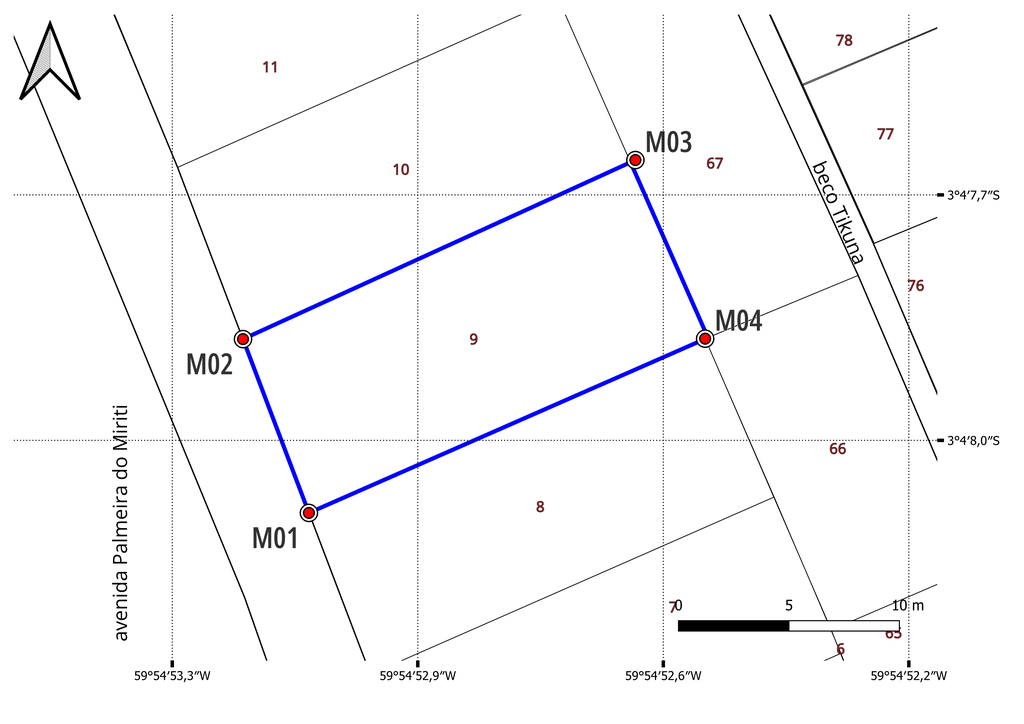

#### Limites e confrontações do terreno

**Frente (OESTE)**: , Corresponde ao segmento que une os marcos M-01 (3°4′8,1″S / 59°54′53,1″W) e M-02 (3°4′7,9″S / 59°54′53,2″W), com comprimento de 8 metros.

**Lateral direita (NORTE)**: Confronta-se com o terreno da casa 10. É constituída pela linha imaginária entre os marcos M-02 (3°4′7,9″S / 59°54′53,2″W) e M-03 (3°4′7,6″S / 59°54′52,6″W), com 20 metros;

**Fundos (LESTE)**: o fundo do terreno é demarcado pelos pontos M-03 (3°4′7,6″S / 59°54′52,6″W) e M-04 (3°4′7,9″S / 59°54′52,5″W), distantes 8 metros entre si.

**Lateral esquerda (SUL)**: Confronta-se com o terreno da casa 8. A linha que une os marcos M-04 (3°4′7,9″S / 59°54′52,5″W) e M-01 (3°4′8,1″S / 59°54′53,1″W) com 20 metros;

Observações:

Manaus, 28 ago 2023.

[output not shown]